# Computer Programming and Algorithms

## Week 9.1: Plotting data

# Aims

In this video we will:

- Introduce the `matplotlib` package
- Show how to create plots of data using `matplotlib.pyplot`

# Matplotlib

Documentation: https://matplotlib.org/

- A comprehensive package for creating static and dynamic visualisations
- A package is a collection of modules
- There are several modules of Matplotlib that handle different types of visualisation
- In this unit, we will study a module called `pyplot`, which is for plotting data

# Importing Matplotlib

We can import the module `pyplot` using

```
import matplotlib.pyplot
```

We will import `pyplot` using the code:

```python
import matplotlib.pyplot as plt
```

The `as` keyword is used to create a user-defined name for `matplotlib.pyplot`; in this case, `plt`

`pyplot` is often *renamed* as `plt` on import, as its shorter to type.

Any functions from `pyplot` can be used by prepending with `plt`

e.g. `plt.plot()`

The import statement should be placed at the top of your Python file

To display plots when running a .py file, the following line must appear in the programme *after* generating the plot:

```python
plt.show()
```

# Line and Scatter Graphs

A sample data set: `x` with corresponding values of `y`:

```python
x = [-1, 3, 4, 8 , 10]
y = [-1, -2, 5, 9 , 11]
```

**Example:** Line plot of `y` against `x`

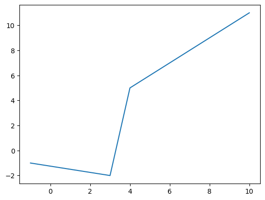

```python
plt.plot(x, y) # scatter, o markers, red

plt.show()
```

**Format string:** an *optional* way to define basic formatting

**Example:** Use the format string to change the appearance of the plot of y against x.

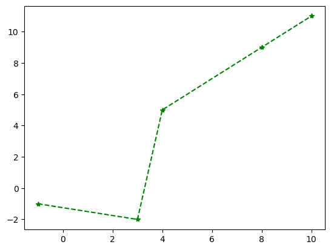

```python
plt.plot(x, y, 'g*--')

plt.show()
```

**Example:** We can add features like axis labels (`plt.xlabel, plt.ylabel`) and a title (`plt.title`)

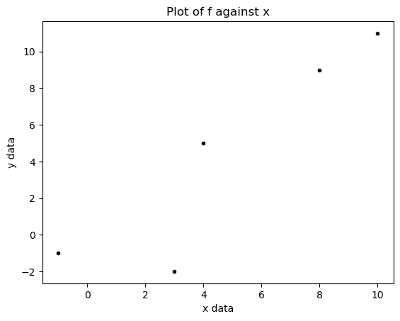

```python
plt.plot(x, y, 'k.')

# Axis labels
plt.xlabel('x data')
plt.ylabel('y data')

# title
plt.title('Plot of f against x')

plt.show()
```

# Multiple series on the same plot

We can give each series of points a name (`plt.label`).

This is useful when multiple series' appear on the same graph.

We can display a key or legend of the data points using `plt.legend`.

**Example:**

Plot `y` against `x` and `f` against `x` on the same graph.

Add a legend to indicate which line shows which relationship.

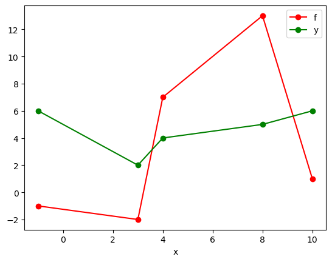

```python
x = [-1, 3, 4, 8 , 10]
f = [-1, -2, 7, 13 , 1]
y = [6, 2, 4, 5, 6]

plt.plot(x, f, '-or', label='f');  # argument 'label' is used in the legend
plt.plot(x, y, '-og', label='y');

plt.xlabel('x');

plt.legend()                      # must be called to display figure legend

plt.show()
```

# Saving plots

Plots can be saved in widely used formats (.png, .pdf etc) specified using the file name extension.

```python
plt.savefig('sample_data/my_plots.png')
```

`plt.savefig` must appear *before* `plt.show()`

# Summary

- `matplotlib.pyplot` contains functions for plotting data
- It is highly customisable, see [the Matplotlib website](https://matplotlib.org/stable/) for full details

### Need to see some more examples?

https://www.w3schools.com/python/matplotlib_intro.asp  
https://www.geeksforgeeks.org/matplotlib-tutorial/

### Want to take a quiz?

https://www.geeksforgeeks.org/quizzes/python-matplotlib-mcq/

### Want some more advanced information?

https://realpython.com/python-matplotlib-guide/